# Project: Investigating a Dataset - **The Movie Database (TMDb)**

- Introduction
- Data Wrangling
- Exploratory Data Analysis
- Conclusions

## Introduction

### **Dataset Columns**

- **id**: Unique identifier for each movie within the dataset.
- **imdb_id**: The movie's IMDb identifier, linking to IMDb for additional information.
- **popularity**: Popularity rating of the movie on TMDb.
- **budget**: Initial production budget of the movie (in USD).
- **revenue**: Total revenue generated by the movie (in USD).
- **original_title**: Original title of the movie.
- **cast**: Main cast members in the movie.
- **homepage**: Official website or homepage of the movie, if available.
- **director**: Director(s) of the movie.
- **tagline**: Catchphrase or slogan associated with the movie.
- **keywords**: Keywords or phrases associated with the movie's themes or content.
- **overview**: Brief summary or synopsis of the movie's plot.
- **runtime**: Duration of the movie in minutes.
- **genres**: Genre(s) that the movie belongs to (e.g., Drama, Action).
- **production_companies**: Companies involved in the production of the movie.
- **release_date**: Official release date of the movie.
- **vote_count**: Number of user reviews or votes on TMDb.
- **vote_average**: Average rating given by users on TMDb.
- **release_year**: Year the movie was released.
- **budget_adj**: Budget of the movie adjusted for inflation to reflect current USD value.
- **revenue_adj**: Revenue of the movie adjusted for inflation to reflect current USD value.

This dataset provides a comprehensive view of each movie’s financial and critical metrics, along with contextual information on cast, production, and thematic elements. Analyzing these variables will help identify factors that may influence movie success.

### Key Questions for Analysis

In this report, I will explore the following questions:

1. **Which genres have been the most popular over the last 10 years?**
2. **What properties are associated with movies that generate high revenues?**
3. **What is the relationship between the movie budget and revenue?**
4. **Does the runtime of a movie impact its revenue generation?**
5. **Is there a correlation between Movie Duration, Popularity, and Revenue?**

## Data Wrangling

In this section, we will load the dataset and assess its quality to ensure it's ready for analysis. This involves identifying and handling missing values, duplicates, and any inconsistencies.

### Importing Required Libraries

To begin our analysis, we will import the necessary libraries that will facilitate data manipulation, visualization, and analysis. The libraries include:

- **Pandas**: For data handling and analysis.
- **NumPy**: For numerical operations.
- **Seaborn**: For advanced data visualization.
- **Matplotlib**: For basic plotting capabilities.

Setting the display option for Pandas will allow us to view all columns in our DataFrame, ensuring a comprehensive look at our dataset.

```python
# Importing required libraries

import pandas as pd
import numpy as np
import seaborn as sns
import matplotlib.pyplot as plt

pd.set_option('display.max_columns', None)  # This will show all columns
```

### Loading the Dataset

In this section, we will load the dataset that contains various attributes related to movies, including budget, revenue, genres, and more. This dataset serves as the foundation for our analysis, allowing us to explore trends, correlations, and insights within the movie industry. Proper loading and initial inspection of the dataset are crucial to understanding its structure and preparing for subsequent data preprocessing steps.

```python
# Load the dataset
data = pd.read_csv('Database_TMDb_movie_data/tmdb-movies.csv')

# Preview the dataframe
data.head()
```

|  | id | imdb_id | popularity | budget | revenue | original_title | cast | homepage | director | tagline | keywords | overview | runtime | genres | production_companies | release_date | vote_count | vote_average | release_year | budget_adj | revenue_adj |
| --- | --- | --- | --- | --- | --- | --- | --- | --- | --- | --- | --- | --- | --- | --- | --- | --- | --- | --- | --- | --- | --- |
| 0 | 135397 | tt0369610 | 32.985763 | 150000000 | 1513528810 | Jurassic World | Chris Pratt\|Bryce Dallas Howard\|Irrfan Khan\|Vi... | http://www.jurassicworld.com/ | Colin Trevorrow | The park is open. | monster\|dna\|tyrannosaurus rex\|velociraptor\|island | Twenty-two years after the events of Jurassic ... | 124 | Action\|Adventure\|Science Fiction\|Thriller | Universal Studios\|Amblin Entertainment\|Legenda... | 6/9/15 | 5562 | 6.5 | 2015 | 1.379999e+08 | 1.392446e+09 |
| 1 | 76341 | tt1392190 | 28.419936 | 150000000 | 378436354 | Mad Max: Fury Road | Tom Hardy\|Charlize Theron\|Hugh Keays-Byrne\|Nic... | http://www.madmaxmovie.com/ | George Miller | What a Lovely Day. | future\|chase\|post-apocalyptic\|dystopia\|australia | An apocalyptic story set in the furthest reach... | 120 | Action\|Adventure\|Science Fiction\|Thriller | Village Roadshow Pictures\|Kennedy Miller Produ... | 5/13/15 | 6185 | 7.1 | 2015 | 1.379999e+08 | 3.481613e+08 |
| 2 | 262500 | tt2908446 | 13.112507 | 110000000 | 295238201 | Insurgent | Shailene Woodley\|Theo James\|Kate Winslet\|Ansel... | http://www.thedivergentseries.movie/#insurgent | Robert Schwentke | One Choice Can Destroy You | based on novel\|revolution\|dystopia\|sequel\|dyst... | Beatrice Prior must confront her inner demons ... | 119 | Adventure\|Science Fiction\|Thriller | Summit Entertainment\|Mandeville Films\|Red Wago... | 3/18/15 | 2480 | 6.3 | 2015 | 1.012000e+08 | 2.716190e+08 |
| 3 | 140607 | tt2488496 | 11.173104 | 200000000 | 2068178225 | Star Wars: The Force Awakens | Harrison Ford\|Mark Hamill\|Carrie Fisher\|Adam D... | http://www.starwars.com/films/star-wars-episod... | J.J. Abrams | Every generation has a story. | android\|spaceship\|jedi\|space opera\|3d | Thirty years after defeating the Galactic Empi... | 136 | Action\|Adventure\|Science Fiction\|Fantasy | Lucasfilm\|Truenorth Productions\|Bad Robot | 12/15/15 | 5292 | 7.5 | 2015 | 1.839999e+08 | 1.902723e+09 |
| 4 | 168259 | tt2820852 | 9.335014 | 190000000 | 1506249360 | Furious 7 | Vin Diesel\|Paul Walker\|Jason Statham\|Michelle ... | http://www.furious7.com/ | James Wan | Vengeance Hits Home | car race\|speed\|revenge\|suspense\|car | Deckard Shaw seeks revenge against Dominic Tor... | 137 | Action\|Crime\|Thriller | Universal Pictures\|Original Film\|Media Rights ... | 4/1/15 | 2947 | 7.3 | 2015 | 1.747999e+08 | 1.385749e+09 |

**Insight**  
The initial rows of the dataset show that the `cast`, `genres`, and `production_companies` columns contain multiple values separated by "|", indicating a need for standardization. Additionally, the `release_date` is formatted as "MM/DD/YY" (e.g., "6/17/15"), which lacks consistency. To enhance data accuracy and facilitate analysis, it is important to convert the `release_date` to a standardized date format and standardize the multivalued entries in the other columns.

### Checking Dataset Dimensions

To understand the structure of the dataset, we will check the total number of rows and columns. This will help us assess the dataset's suitability for our analysis.

```python
# Check how many total rows and columns
data.shape
```

```
(10866, 21)
```

**Insight**  
The dataset contains 10,866 entries and 21 columns, offering extensive information for analysis. This large size and variety of variables present opportunities for uncovering trends, but also require careful preprocessing to ensure accurate insights.

### Displaying Dataset Information

Next, we will display a summary of the dataset to understand its structure, including data types and non-null counts for each column. This information is essential for identifying any data quality issues.

```python
# Display information about the dataset
print("DataFrame summary:")

data.info()
```

```
DataFrame summary:
<class 'pandas.core.frame.DataFrame'>
RangeIndex: 10866 entries, 0 to 10865
Data columns (total 21 columns):
 #   Column                Non-Null Count  Dtype
---  ------                --------------  -----
 0   id                    10866 non-null  int64
 1   imdb_id               10856 non-null  object
 2   popularity            10866 non-null  float64
 3   budget                10866 non-null  int64
 4   revenue               10866 non-null  int64
 5   original_title        10866 non-null  object
 6   cast                  10790 non-null  object
 7   homepage              2936 non-null   object
 8   director              10822 non-null  object
 9   tagline               8042 non-null   object
 10  keywords              9373 non-null   object
 11  overview              10862 non-null  object
 12  runtime               10866 non-null  int64
 13  genres                10843 non-null  object
 14  production_companies  9836 non-null   object
 15  release_date          10866 non-null  object
 16  vote_count            10866 non-null  int64
 17  vote_average          10866 non-null  float64
 18  release_year          10866 non-null  int64
 19  budget_adj            10866 non-null  float64
 20  revenue_adj           10866 non-null  float64
dtypes: float64(4), int64(6), object(11)
memory usage: 1.7+ MB
```

**Insight**  
The DataFrame consists of 10,866 entries and 21 columns, featuring various data types. While most columns, such as `popularity` and `revenue`, are fully populated, several, including `imdb_id`, `cast`, and `homepage`, contain missing values, which could affect analysis. The dataset's memory usage exceeds 1.7 MB, indicating efficient storage. To streamline the analysis and focus on the most relevant variables, I recommend dropping the following columns:

- **imdb_id**: Redundant since information can be derived from TMDb.
- **homepage**: Contains minimal analytical value.
- **tagline**: Not essential for analyzing revenue or popularity.
- **overview**: Complicates quantitative analysis without adding significant value.
- **cast**: Can be analyzed separately if focusing on genre and financial metrics.

By narrowing the dataset in this way, I can concentrate on key variables that directly relate to my research questions, enhancing the clarity and depth of the analysis while ensuring robust insights.

```python
# Drop unnecessary columns to streamline analysis
data.drop(columns=['imdb_id', 'homepage', 'tagline', 'overview', 'cast'], inplace=True)
```

The specified columns have been removed to focus on the most relevant variables. This will enhance the clarity of the analysis and ensure that insights are derived from key data points directly related to the research questions.

### Describing the Dataset

We will now generate descriptive statistics for the dataset. This will provide insights into the central tendencies, variability, and distribution of the numerical features, helping us understand the data better.

```python
# Describe the dataset

data.describe()
```

|  | id | popularity | budget | revenue | runtime | vote_count | vote_average | release_year | budget_adj | revenue_adj |
| --- | --- | --- | --- | --- | --- | --- | --- | --- | --- | --- |
| count | 10866.000000 | 10866.000000 | 1.086600e+04 | 1.086600e+04 | 10866.000000 | 10866.000000 | 10866.000000 | 10866.000000 | 1.086600e+04 | 1.086600e+04 |
| mean | 66064.177434 | 0.646441 | 1.462570e+07 | 3.982332e+07 | 102.070863 | 217.389748 | 5.974922 | 2001.322658 | 1.755104e+07 | 5.136436e+07 |
| std | 92130.136561 | 1.000185 | 3.091321e+07 | 1.170035e+08 | 31.381405 | 575.619058 | 0.935142 | 12.812941 | 3.430616e+07 | 1.446325e+08 |
| min | 5.000000 | 0.000065 | 0.000000e+00 | 0.000000e+00 | 0.000000 | 10.000000 | 1.500000 | 1960.000000 | 0.000000e+00 | 0.000000e+00 |
| 25% | 10596.250000 | 0.207583 | 0.000000e+00 | 0.000000e+00 | 90.000000 | 17.000000 | 5.400000 | 1995.000000 | 0.000000e+00 | 0.000000e+00 |
| 50% | 20669.000000 | 0.383856 | 0.000000e+00 | 0.000000e+00 | 99.000000 | 38.000000 | 6.000000 | 2006.000000 | 0.000000e+00 | 0.000000e+00 |
| 75% | 75610.000000 | 0.713817 | 1.500000e+07 | 2.400000e+07 | 111.000000 | 145.750000 | 6.600000 | 2011.000000 | 2.085325e+07 | 3.369710e+07 |
| max | 417859.000000 | 32.985763 | 4.250000e+08 | 2.781506e+09 | 900.000000 | 9767.000000 | 9.200000 | 2015.000000 | 4.250000e+08 | 2.827124e+09 |

### Financial Insights

From our analysis of the dataset, we found some interesting financial details about the movies:

- **Average Budget**: About `$14.63 million`
- **Average Revenue**: Around `$39.83 million`
- **Maximum Budget**: `$425 million`
- **Maximum Revenue**: `$2.78 billion`

### Data Cleaning

In this section, we will address issues identified during data wrangling to ensure the dataset is clean for analysis. After each relevant code cell, we will summarize findings and actions taken for clarity.

### Handling Missing Values

Before diving into the analysis, it's essential to address any missing values in the dataset. Missing data can significantly impact our results, so we'll define various indicators for missing values, including empty strings, spaces, and common placeholders. After identifying these indicators, we'll replace them with pandas' NA value for better handling.

Next, we'll assess the extent of missing data by counting the number of missing values in each column and calculating the percentage of missing entries relative to the total number of rows. This will help us understand the completeness of our dataset and guide our cleaning process.

```python
# Define indicators for missing values across different formats (e.g., empty strings, spaces, dashes, 'missing')
missing_value_indicators = ['', ' ', '-', '--', 'missing', 'Missing', 'N/A', 'n/a', None]

# Replace any detected missing value indicators in the product_sales DataFrame with pandas' NA value
data.replace(missing_value_indicators, pd.NA, inplace=True)

# Identify and count the missing values in each column of the product_sales DataFrame
missing_data = data.isna().sum()

# Calculate the total number of rows in the DataFrame for reference
total_rows = data.shape[0]

# Compute the percentage of missing data for each column based on the total number of rows
missing_percentage = (missing_data / total_rows) * 100

# Create a summary DataFrame that combines both the counts and percentages of missing data
missing_summary = pd.DataFrame({
    'Missing Values': missing_data,
    'Percentage': missing_percentage
})

# Output the summary table to provide an overview of missing data in the dataset
print("Summary of Missing Values:")
missing_summary
```

```
Summary of Missing Values:
```

|  | Missing Values | Percentage |
| --- | --- | --- |
| id | 0 | 0.000000 |
| popularity | 0 | 0.000000 |
| budget | 0 | 0.000000 |
| revenue | 0 | 0.000000 |
| original_title | 1 | 0.009203 |
| director | 44 | 0.404933 |
| keywords | 1493 | 13.740107 |
| runtime | 0 | 0.000000 |
| genres | 23 | 0.211669 |
| production_companies | 1030 | 9.479109 |
| release_date | 0 | 0.000000 |
| vote_count | 0 | 0.000000 |
| vote_average | 0 | 0.000000 |
| release_year | 0 | 0.000000 |
| budget_adj | 0 | 0.000000 |
| revenue_adj | 0 | 0.000000 |

### Insight on Missing Values

The missing values analysis indicates:

- **High Completeness**: Key columns like `id`, `popularity`, `budget`, `revenue`, `runtime`, and `release_date` are free of missing entries.
- **Minimal Impact**: The `original_title` column has only **1 missing value** (0.01%).
- **Moderate Missing Data**: The `director` column has **44 missing values** (0.40%), and `genres` has **23** (0.21%), which may affect related analyses.
- **Significant Gaps**: The `keywords` column has **1,493 missing values** (13.74%), while `production_companies` shows **1,030** (9.48%). These gaps are substantial enough to warrant caution in analyses relying on these attributes.

Overall, the dataset is generally complete, but addressing missing values in `keywords` and `production_companies` is crucial for robust analysis.

### Next Steps

Based on the summary of missing values, we will take the following actions:

1. **Drop Columns**: We will consider dropping columns like `keywords` and `production_companies`, as they contain significant amounts of missing data and are less critical for addressing our key questions.
2. **Impute Values**: For columns like `director` and `genres`, where the missing data is moderate, we will impute missing values with "unknown" to retain important information without introducing bias.
3. **Handle `original_title`**: The `original_title` column contains only one missing value. We will drop this column, as its minimal impact does not warrant retention.

By implementing these strategies, we aim to enhance the dataset's quality, ensuring that our analysis effectively addresses the key research questions.

```python
# Drop the 'original_title' column due to its minimal impact on analysis
data.drop(columns=['original_title'], inplace=True)

# Impute missing values for 'director' and 'genres' with 'unknown'
data['director'].fillna('unknown', inplace=True)
data['genres'].fillna('unknown', inplace=True)

# Drop columns with excessive missing values: 'keywords' and 'production_companies'
data.drop(columns=['keywords', 'production_companies'], inplace=True)

# Display the count of remaining missing values
remaining_missing = data.isna().sum().sum()
print("Remaining missing values in the DataFrame:", remaining_missing)
```

```
Remaining missing values in the DataFrame: 0
```

This code drops the `original_title` column and imputes "unknown" for missing values in the `director` and `genres` columns. We also remove `keywords` and `production_companies` due to high missing rates. A final check confirms no missing values remain.

### Removing Duplicate Rows

To ensure the integrity of our dataset, we will check for and remove any duplicate rows. This step is crucial, as duplicates can skew our analysis and lead to inaccurate results. After identifying the duplicates, we will remove them from the dataset.

```python
# Count duplicate rows
duplicate_count = data.duplicated(keep=False).sum()

# Remove all duplicates in place
data.drop_duplicates(keep=False, inplace=True)

# Print the number of removed duplicates, with a conditional message
if duplicate_count > 0:
    msg = f"Number of duplicate rows removed: {duplicate_count}"
else:
    msg = "No duplicate rows found."
print(msg)
```

```
Number of duplicate rows removed: 2
```

Two duplicate rows were identified in the dataset. These duplicates will be removed to ensure that our analysis is based on unique entries, enhancing the accuracy and reliability of the results.

```python
# Drop duplicates
data.drop_duplicates(inplace=True)

# Count duplicate rows again
duplicate_count = data.duplicated(keep=False).sum()

duplicate_count
```

```
0
```

All duplicate rows have been successfully removed from the dataset. This step helps ensure that the analysis reflects unique entries, thereby improving the integrity of our findings. The dataset is now ready for further analysis without the influence of redundant data.

### Converting `release_date` to Datetime Format

We will convert the `release_date` column to datetime format to enable time-based analyses effectively.

```python
# Convert the 'release_date' column to datetime format
data['release_date'] = pd.to_datetime(data['release_date'], errors='coerce')
```

This conversion ensures that the `release_date` is in a suitable format for further analysis.

### Conclusion of Data Cleaning

After implementing the necessary data cleaning steps, we have ensured that our dataset is now free of duplicates and missing values. The data is well-structured and refined, making it ready for analysis. We can confidently proceed with exploring the key research questions outlined in this report.

### Function for Regression Chart Visualization

To analyze the relationships between various numerical variables in our dataset, we can define a function that creates a regression chart. This function will take in parameters for the x and y variables, allowing us to visualize the correlation between them through a scatter plot with a regression line. The correlation coefficient will be calculated and displayed on the plot, providing insight into the strength of the relationship.

The following function will enable us to generate these regression charts efficiently for any specified variables in our analysis:

```python
# Import required libraries
import matplotlib.pyplot as plt
import seaborn as sns
from scipy.stats import linregress

# Define the function for drawing regression charts
def draw_regression_chart(x, y, data):
    """
    Draws a regression chart with a scatter plot and a regression line between two variables.
    Calculates and returns the correlation coefficient.

    Parameters:
    x (str): The column name for the x-axis variable.
    y (str): The column name for the y-axis variable.
    data (pd.DataFrame): The data frame containing the data.

    Returns:
    float: The correlation coefficient between x and y.
    """
    # Filter the DataFrame for non-zero values in both x and y columns
    filtered_data = data[(data[x] > 0) & (data[y] > 0)]

    # Set the plot size
    plt.figure(figsize=(12, 6))

    # Create a scatter plot with a regression line
    sns.regplot(x=x, y=y, data=filtered_data, scatter_kws={'alpha': 0.5}, line_kws={'color': 'red'})

    # Calculate the correlation coefficient
    correlation = filtered_data[x].corr(filtered_data[y])

    # Set plot title and labels
    plt.title(f'Relationship between Movie {x.capitalize()} and {y.capitalize()}', fontsize=16)
    plt.xlabel(f'{x.capitalize()} (in appropriate units)', fontsize=14)
    plt.ylabel(f'{y.capitalize()} (in dollars)', fontsize=14)

    # Display the correlation score on the plot
    plt.annotate(f'Correlation: {correlation:.2f}', xy=(0.05, 0.95), xycoords='axes fraction', fontsize=12, color='black')

    # Show the plot
    plt.grid()
    plt.show()

    return correlation
```

## Exploratory Data Analysis

### **1. Which genres have been the most popular over the last 10 years?**

This question aims to identify the most frequently occurring genres in films released from 2006 to 2015, analyzing their counts to determine trends in audience preferences during this period.

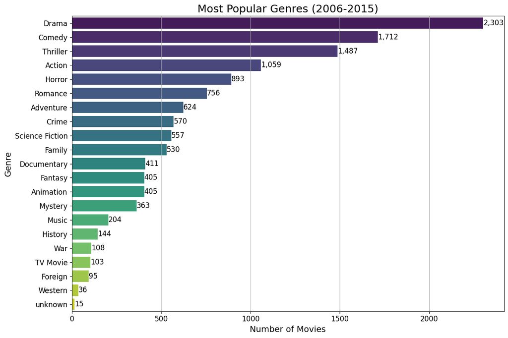

```python
# Filter the dataset for the last 10 years (2006 to 2015)
last_10_years_data = data[(data['release_year'] >= 2006) & (data['release_year'] <= 2015)]

# Split the genres and explode the DataFrame to count occurrences
genres_exploded = last_10_years_data['genres'].str.split('|', expand=True).stack()

# Create a DataFrame from the exploded genres
genres_df = genres_exploded.reset_index(level=1, drop=True).to_frame('genre')

# Count the occurrences of each genre
genre_counts = genres_df['genre'].value_counts()

# Convert the counts to a DataFrame for better visualization
genre_counts_df = genre_counts.reset_index()
genre_counts_df.columns = ['Genre', 'Count']

# Sort the DataFrame in descending order by count
genre_counts_df.sort_values(by='Count', ascending=False, inplace=True)

# Create a horizontal bar chart using Seaborn
plt.figure(figsize=(12, 8))  # Adjusting figure size
bar_plot = sns.barplot(x='Count', y='Genre', data=genre_counts_df, palette='viridis')

# Adding values on top of each bar
for index, value in enumerate(genre_counts_df['Count']):
    bar_plot.text(value, index, f'{value:,}', va='center', fontsize=12)

plt.title('Most Popular Genres (2006-2015)', fontsize=18)
plt.xlabel('Number of Movies', fontsize=14)
plt.ylabel('Genre', fontsize=14)
plt.xticks(fontsize=12)
plt.yticks(fontsize=12)
plt.grid(axis='x')

# Show the plot
plt.tight_layout()
plt.show()
```

### Insights on Genre Popularity (2006-2015)

Looking at the movie genres released between 2006 and 2015, it’s clear that **Drama** tops the list as the most popular genre, with a whopping **2,303** films. This strong presence indicates that audiences really connect with dramatic storytelling.

Following close behind is **Comedy**, which boasts **1,712** films. It seems people enjoy a good laugh, as humor continues to be a major draw for moviegoers. The **Thriller** genre also has a significant stake, with **1,487** films keeping viewers on the edge of their seats. **Action** movies aren’t far behind, with **1,059** films, catering to fans looking for excitement and adventure.

On the other hand, **Horror** remains a popular choice, with **893** films released, proving that there’s a consistent appetite for chills and thrills. Meanwhile, **Romance** holds its ground with **756** films, showcasing the enduring appeal of love stories.

Genres like **Adventure** and **Science Fiction** also make their mark, with **624** and **557** films, respectively. These genres offer audiences a chance to escape into fantastical worlds. Family films come in at **530**, suggesting that there's plenty of content for viewers of all ages.

However, some genres, like **Western** and **Foreign** films, appear less frequently, with counts of **36** and **95**, respectively. This suggests they cater to more niche audiences. Interestingly, there are **15 films** labeled as **unknown**, pointing to some inconsistencies in how genres were classified in the dataset.

### **2. What Genre Generates the Highest Average Revenue?**

To determine which genre of movies generates the highest average revenue, we will analyze the dataset and calculate the average revenue for each genre. Given that movies can belong to multiple genres, we will extract these genres and use a dictionary to facilitate our calculations. After processing, we will identify the genre with the highest average revenue and present our findings in a clear and professional format.

Let's proceed with the analysis.

```python
# Create a new DataFrame to avoid modifying the original
exploded_data = data.copy()

# Split the genres into separate entries
exploded_data['genres'] = exploded_data['genres'].str.split('|')

# Explode the DataFrame to have one genre per row
exploded_data = exploded_data.explode('genres')

# Group by genre and calculate average revenue
average_revenue_by_genre = exploded_data.groupby('genres')['revenue'].mean().reset_index()

# Find the genre with the maximum average revenue
max_revenue_genre = average_revenue_by_genre.loc[average_revenue_by_genre['revenue'].idxmax()]

# Print the result
print(f"The genre with the highest average revenue is '{max_revenue_genre['genres']}' "
      f"with an average revenue of ${max_revenue_genre['revenue']:,.2f}.")
```

```
The genre with the highest average revenue is 'Adventure' with an average revenue of $113,137,861.07.
```

The analysis reveals that the **Adventure** genre leads in average revenue generation, with an impressive average of **$113,137,861.07**. This insight highlights the financial potential of Adventure films, indicating their strong market appeal and audience engagement, which could inform future production and marketing strategies in the film industry.

### **3. What is the relationship between the movie budget and revenue?**

In this analysis, we will explore the relationship between movie budgets and revenues. Understanding this relationship can provide valuable insights into how financial investments in film production influence box office performance. We will create a scatter plot to visualize this relationship, along with a regression line to illustrate the trend. Additionally, we will calculate the correlation coefficient to quantify the strength of the relationship.

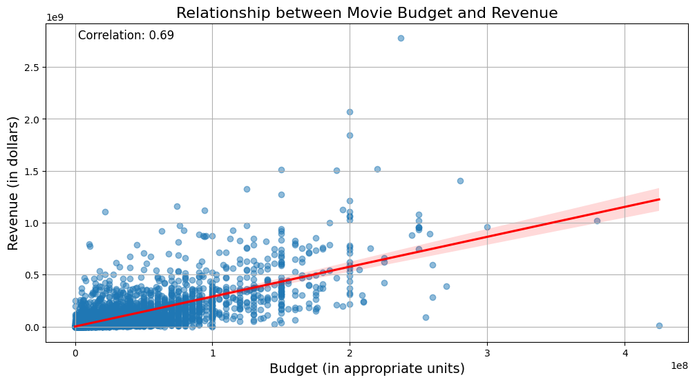

```python
correlation_budget_revenue = draw_regression_chart('budget', 'revenue', data)
```

The correlation coefficient of 0.69 indicates a strong positive relationship between movie budgets and revenues. This suggests that, generally, films with higher budgets tend to generate greater revenues. While this correlation is significant, it is essential to consider other factors such as marketing, audience appeal, and critical reception, which can also influence a film's box office success.

### **4. Does the runtime of a movie impact its revenue generation?**

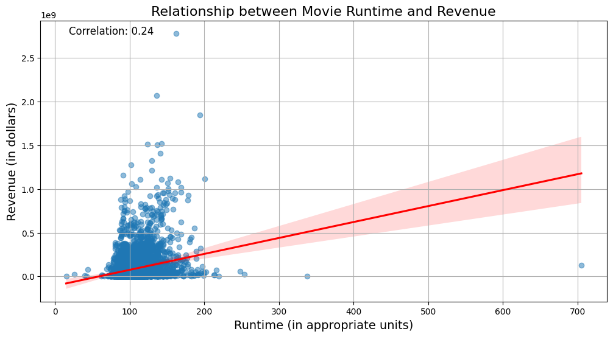

```python
correlation_runtime_revenue = draw_regression_chart('runtime', 'revenue', data)
```

### **5. Is there a correlation between Movie Duration, Popularity, and Revenue?**

By investigating the relationships between these three variables, we aim to determine how movie runtime and popularity jointly impact revenue. Specifically, we’ll analyze whether longer or shorter movies have different popularity levels and how these factors correlate with the revenue generated.

In this analysis, we examine the relationship between movie runtime, popularity, and revenue. By calculating the correlation between these variables, we aim to understand the extent to which each factor contributes to a movie's financial success. A higher correlation between popularity and revenue, for example, may suggest that popularity is a significant driver of revenue, regardless of runtime. Conversely, if runtime shows only a weak relationship with both popularity and revenue, it may indicate that factors other than duration are more influential in determining a movie's success.

The correlation matrix calculated below will provide us with quantitative insights into these relationships.

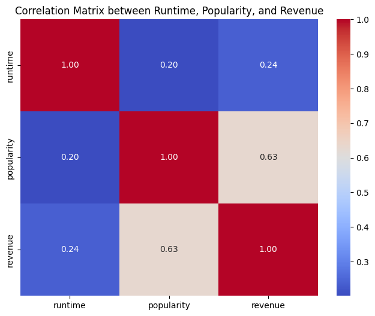

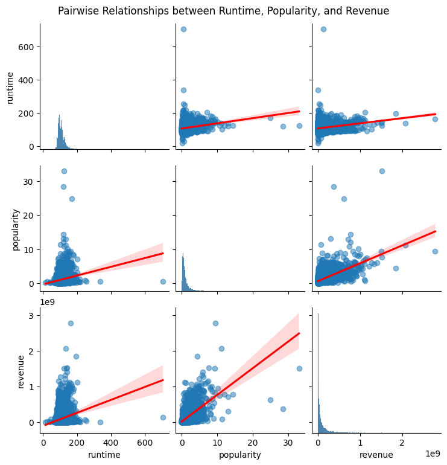

```python
# Filter the DataFrame to include only relevant columns and non-zero values for revenue and popularity
filtered_data = data[(data['runtime'] > 0) & (data['revenue'] > 0) & (data['popularity'] > 0)][['runtime', 'popularity', 'revenue']]

# Calculate the correlation matrix
correlation_matrix = filtered_data.corr()

# Visualize the correlation matrix as a heatmap for easier interpretation
plt.figure(figsize=(8, 6))
sns.heatmap(correlation_matrix, annot=True, cmap='coolwarm', fmt=".2f")
plt.title('Correlation Matrix between Runtime, Popularity, and Revenue')
plt.show()

# Visualize the relationships with pair plots to explore possible trends
sns.pairplot(filtered_data, kind='reg', plot_kws={'line_kws':{'color':'red'}, 'scatter_kws':{'alpha':0.5}})
plt.suptitle('Pairwise Relationships between Runtime, Popularity, and Revenue', y=1.02)
plt.show()
```

### Insight

1. **Popularity vs. Revenue**
   - **Correlation:** 0.63 (moderate positive correlation)
   - **Implication:** Movies with higher popularity tend to generate more revenue. Popularity appears to be a key driver of financial success, making it an important focus for maximizing box office performance.
2. **Runtime vs. Revenue**
   - **Correlation:** 0.24 (weak positive correlation)
   - **Implication:** Longer movies have a slight association with higher revenue, but runtime alone is not a significant predictor of financial performance.
3. **Runtime vs. Popularity**
   - **Correlation:** 0.20 (weak positive correlation)
   - **Implication:** Movie duration has minimal impact on popularity, suggesting that audiences are drawn to factors other than length when choosing a film.

### Overall Conclusion:

Popularity plays a considerably stronger role than runtime in driving revenue, indicating that efforts to enhance a movie’s popularity are likely more effective for financial success than focusing solely on runtime. This insight provides valuable guidance for producers and marketers aiming to maximize movie revenue.

## Conclusion

This analysis explored key aspects of the film industry, emphasizing the relationships between genre popularity, revenue generation, and other influential variables. The findings provide valuable insights for filmmakers and marketers aiming to enhance their understanding of audience preferences and financial success in the competitive landscape of cinema.

### Limitations

While the findings provide valuable insights, there are inherent limitations:

- **Causation vs. Correlation**: The analysis primarily identifies correlations, which do not imply causation. Further research utilizing statistical testing would be beneficial to clarify these relationships.
- **Influential Factors**: Other variables, such as star power, director choices, and marketing strategies, were not examined in detail, which may influence a film's financial outcomes.

### Recommendations for Future Research

- **Deeper Analysis**: Future studies could investigate the specific factors that enhance popularity and revenue, such as:
  - Star actor influence
  - Director effectiveness
  - Marketing strategies
- **Emerging Trends**: Exploring the impact of new genres and shifting viewer preferences will provide filmmakers with comprehensive insights for successful project development.

```python
# Running this cell will execute a bash command to convert this notebook to an .html file
!python -m nbconvert --to html Investigate_a_Dataset.ipynb
```

```
[NbConvertApp] Converting notebook Investigate_a_Dataset.ipynb to html
[NbConvertApp] WARNING | Alternative text is missing on 5 image(s).
[NbConvertApp] Writing 836814 bytes to Investigate_a_Dataset.html
```